# Fires clean

candice

2022-12-02

## Exploration

First, let’s look at the data and try to fit a model to our data distribution.

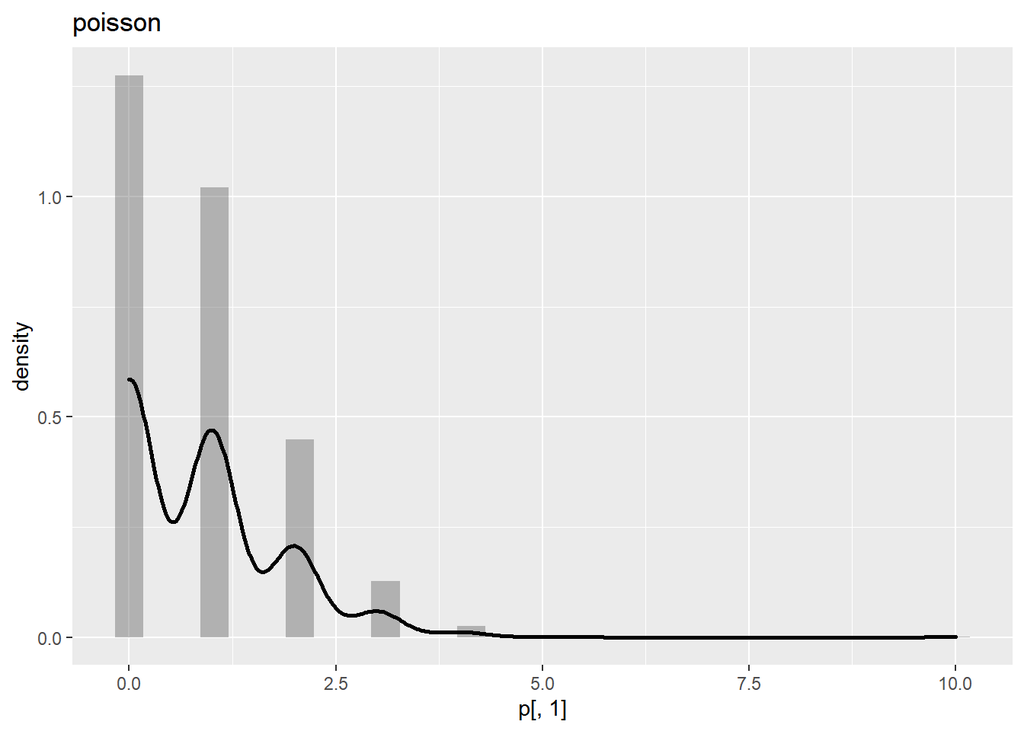

To fit a model, let’s look at the correlations between the different variables and their distributions. This will enable us to understand better how they are possibly linked.

[output not shown]

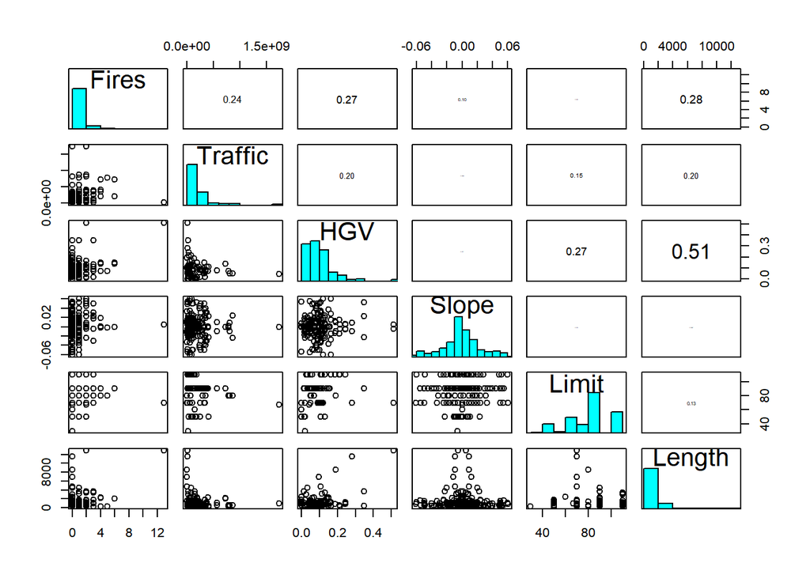

It looks like Fires are correlated with Traffic, HGV and Length.  
Length and HGV are correlated too so we should take this is account when we will try to fit the model.

## Model

*Variable selection for linear model* The first naive way to do it is to do a backward elimination on all the variables. But it gives a model based on companies and tunnel mainly, which is not a true model. Indeed, those effects are random. So, we do the backward elimination without those variables.

```
## Start:  AIC=99.66
## Fires ~ log(Traffic) + HGV + Slope + Limit + log(Length) + Direction +
##     Urban + Type + Length + Traffic
##
##                Df Sum of Sq    RSS     AIC
## - Type          1    0.2329 268.67  97.804
## - Traffic       1    0.2429 268.68  97.810
## - Limit         1    0.2871 268.72  97.838
## - Urban         1    1.3053 269.74  98.481
## - Length        1    2.3214 270.75  99.120
## - log(Length)   1    2.8294 271.26  99.439
## - Direction     1    2.8530 271.29  99.454
## <none>                      268.43  99.657
## - Slope         1    3.5529 271.99  99.892
## - log(Traffic)  1   10.4138 278.85 104.127
## - HGV           1   16.0259 284.46 107.514
##
## Step:  AIC=97.8
## Fires ~ log(Traffic) + HGV + Slope + Limit + log(Length) + Direction +
##     Urban + Length + Traffic
##
##                Df Sum of Sq    RSS     AIC
## - Limit         1    0.1575 268.82  95.904
## - Traffic       1    0.2093 268.88  95.936
## - Urban         1    1.3948 270.06  96.684
## - Length        1    2.3067 270.97  97.257
## - log(Length)   1    2.6442 271.31  97.469
## - Direction     1    3.0408 271.71  97.717
## <none>                      268.67  97.804
## - Slope         1    3.5476 272.21  98.034
## - log(Traffic)  1   11.7053 280.37 103.054
## - HGV           1   15.9681 284.63 105.619
##
## Step:  AIC=95.9
## Fires ~ log(Traffic) + HGV + Slope + log(Length) + Direction +
##     Urban + Length + Traffic
##
##                Df Sum of Sq    RSS     AIC
## - Traffic       1    0.2987 269.12  94.092
## - Urban         1    2.0112 270.83  95.171
```

[output cut: 40 more lines]

```
## <none>                      272.53  92.234
## - Slope         1     3.512 276.05  92.411
## - HGV           1    13.323 285.86  98.348
## - Length        1    38.461 311.00 112.677
## - log(Traffic)  1    73.665 346.20 130.907
##
## Step:  AIC=92.16
## Fires ~ log(Traffic) + HGV + Slope + Length
##
##                Df Sum of Sq    RSS     AIC
## <none>                      275.64  92.158
## - Slope         1     4.005 279.64  92.610
## - HGV           1    12.942 288.58  97.959
## - Length        1    37.660 313.30 111.930
## - log(Traffic)  1    71.900 347.54 129.562
```

```
##
## Call:
## lm(formula = Fires ~ log(Traffic) + HGV + Slope + Length, data = Fires)
##
## Residuals:
##     Min      1Q  Median      3Q     Max
## -3.3266 -0.7590 -0.1040  0.4918  8.3951
##
## Coefficients:
##                Estimate Std. Error t value Pr(>|t|)
## (Intercept)  -1.020e+01  1.606e+00  -6.348 2.03e-09 ***
## log(Traffic)  5.543e-01  8.449e-02   6.561 6.61e-10 ***
## HGV           3.946e+00  1.418e+00   2.783  0.00601 **
## Slope         6.196e+00  4.002e+00   1.548  0.12346
## Length        2.711e-04  5.709e-05   4.748 4.43e-06 ***
## ---
## Signif. codes:  0 '***' 0.001 '**' 0.01 '*' 0.05 '.' 0.1 ' ' 1
##
## Residual standard error: 1.292 on 165 degrees of freedom
## Multiple R-squared:  0.2957, Adjusted R-squared:  0.2786
## F-statistic: 17.32 on 4 and 165 DF,  p-value: 7.016e-12
```

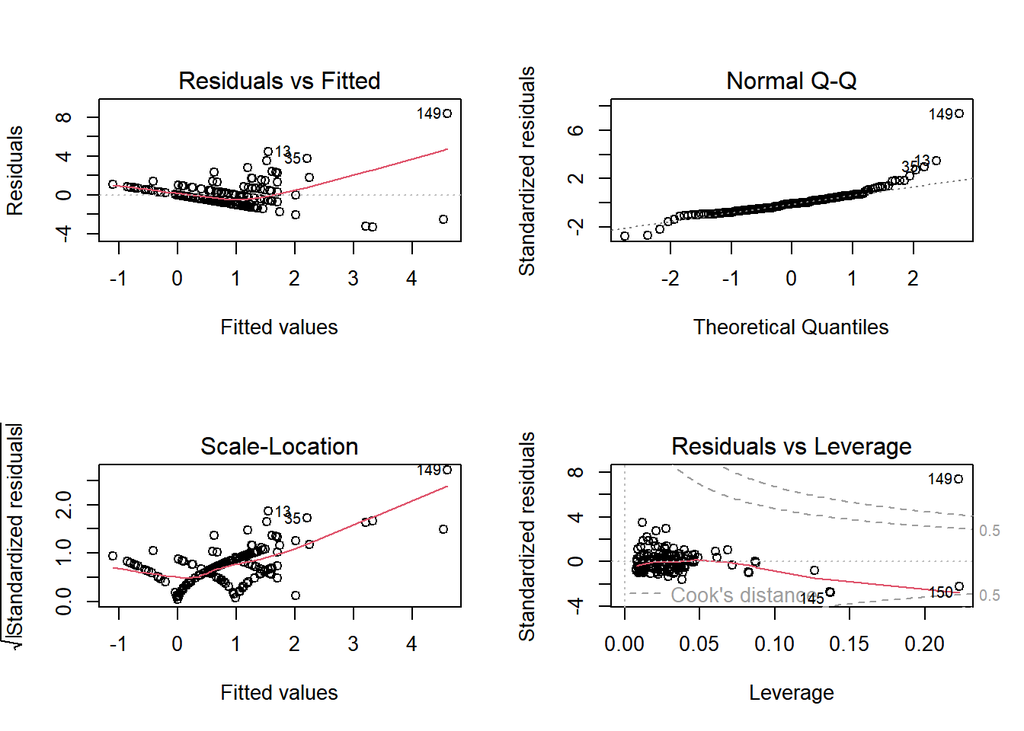

The multiple R squared is not that good and the Slope coefficient is not significant. This might not be the best model at all. The distribution was close to a poisson, so let’s try to fit poisson models.

*Poisson model* First, as previously, I do a variable selection based on the AIC and BIC.

```
## Start:  AIC=364.96
## Fires ~ log(Traffic) + HGV + Slope + Limit + log(Length) + Direction +
##     Urban + Type + Length + Traffic
##
##                Df Deviance    AIC
## - Urban         1   174.01 363.09
## - Length        1   174.18 363.25
## - Type          1   174.74 363.82
## - Limit         1   174.82 363.89
## <none>              173.89 364.96
## - Direction     1   176.47 365.55
## - Slope         1   179.39 368.46
## - Traffic       1   180.14 369.21
## - log(Length)   1   182.86 371.94
## - HGV           1   187.87 376.94
## - log(Traffic)  1   202.70 391.78
##
## Step:  AIC=363.09
## Fires ~ log(Traffic) + HGV + Slope + Limit + log(Length) + Direction +
##     Type + Length + Traffic
##
##                Df Deviance    AIC
## - Length        1   174.25 361.32
## - Limit         1   174.82 361.90
## - Type          1   174.82 361.90
## <none>              174.01 363.09
## - Direction     1   176.61 363.68
## - Slope         1   179.49 366.57
## - Traffic       1   181.03 368.10
## - log(Length)   1   183.14 370.22
## - HGV           1   189.71 376.79
## - log(Traffic)  1   227.57 414.65
##
## Step:  AIC=361.32
## Fires ~ log(Traffic) + HGV + Slope + Limit + log(Length) + Direction +
##     Type + Traffic
##
##                Df Deviance    AIC
## - Type          1   175.02 360.10
## - Limit         1   175.83 360.90
```

[output cut: 19 more lines]

```
## - HGV           1   211.80 394.88
## - log(Traffic)  1   242.49 425.56
##
## Step:  AIC=359.09
## Fires ~ log(Traffic) + HGV + Slope + log(Length) + Direction +
##     Traffic
##
##                Df Deviance    AIC
## <none>              176.01 359.09
## - Direction     1   178.83 359.91
## - Slope         1   181.36 362.43
## - Traffic       1   182.27 363.35
## - log(Length)   1   209.76 390.84
## - HGV           1   211.86 392.94
## - log(Traffic)  1   242.69 423.76
```

The final model is the following one :

```
##
## Call:
## glm(formula = Fires ~ log(Traffic) + HGV + Slope + log(Length) +
##     Direction + Traffic, family = "poisson", data = Fires)
##
## Deviance Residuals:
##     Min       1Q   Median       3Q      Max
## -2.1459  -0.9950  -0.4059   0.4669   2.6751
##
## Coefficients:
##                        Estimate Std. Error z value Pr(>|z|)
## (Intercept)          -2.773e+01  3.702e+00  -7.490 6.90e-14 ***
## log(Traffic)          1.178e+00  1.809e-01   6.510 7.50e-11 ***
## HGV                   6.359e+00  1.111e+00   5.726 1.03e-08 ***
## Slope                 8.890e+00  3.862e+00   2.302   0.0214 *
## log(Length)           7.154e-01  1.260e-01   5.676 1.38e-08 ***
## DirectionDirection 2 -2.887e-01  1.732e-01  -1.667   0.0955 .
## Traffic              -1.161e-09  5.203e-10  -2.232   0.0256 *
## ---
## Signif. codes:  0 '***' 0.001 '**' 0.01 '*' 0.05 '.' 0.1 ' ' 1
##
## (Dispersion parameter for poisson family taken to be 1)
##
##     Null deviance: 322.16  on 169  degrees of freedom
## Residual deviance: 176.01  on 163  degrees of freedom
## AIC: 359.09
##
## Number of Fisher Scoring iterations: 6
```

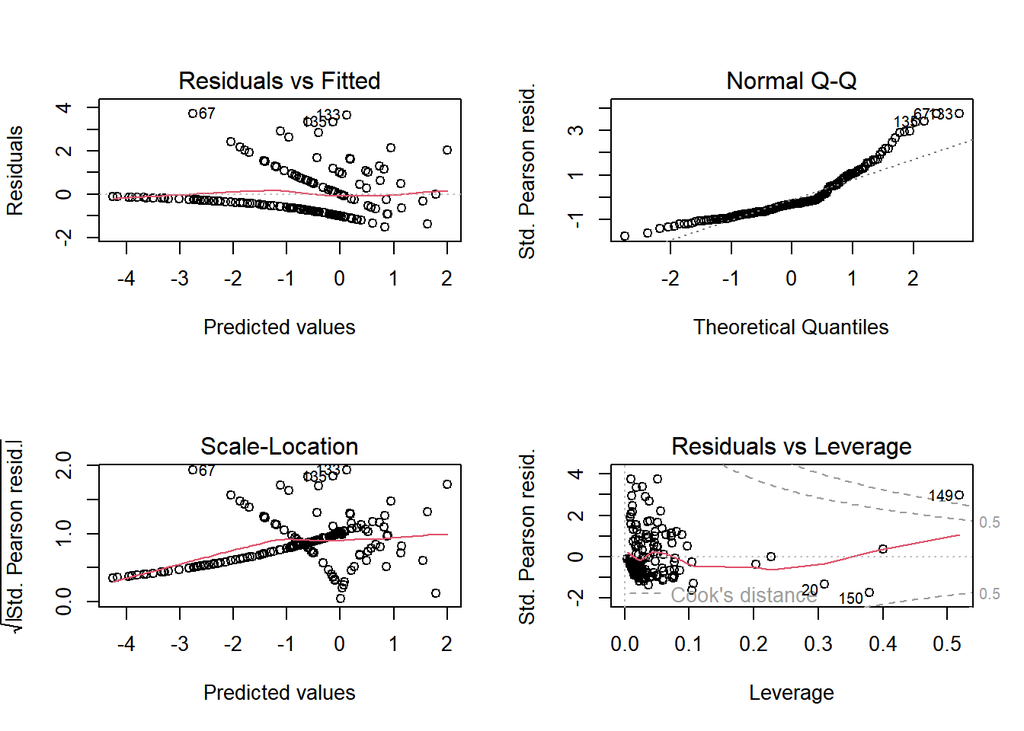

This model can probably be improved since some coefficients are not significant. Let’s try to see if we can improve the model.

```
##
## Call:
## glm(formula = Fires ~ log(Traffic) + HGV + log(Length), family = "poisson",
##     data = Fires)
##
## Deviance Residuals:
##     Min       1Q   Median       3Q      Max
## -2.7271  -1.0384  -0.5034   0.4395   2.8400
##
## Coefficients:
##               Estimate Std. Error z value Pr(>|z|)
## (Intercept)  -20.74042    2.13772  -9.702  < 2e-16 ***
## log(Traffic)   0.81806    0.09049   9.040  < 2e-16 ***
## HGV            5.49984    1.00758   5.458  4.8e-08 ***
## log(Length)    0.64439    0.12372   5.208  1.9e-07 ***
## ---
## Signif. codes:  0 '***' 0.001 '**' 0.01 '*' 0.05 '.' 0.1 ' ' 1
##
## (Dispersion parameter for poisson family taken to be 1)
##
##     Null deviance: 322.16  on 169  degrees of freedom
## Residual deviance: 191.59  on 166  degrees of freedom
## AIC: 368.67
##
## Number of Fisher Scoring iterations: 5
```

[figure not shown]

First, we put Tunnel as the random effect

```
## Generalized linear mixed model fit by maximum likelihood (Laplace
##   Approximation) [glmerMod]
##  Family: poisson  ( log )
## Formula: Fires ~ log(Traffic) + HGV + log(Length) + (1 | Tunnel)
##    Data: Fires
##
##      AIC      BIC   logLik deviance df.resid
##    362.6    378.3   -176.3    352.6      165
##
## Scaled residuals:
##     Min      1Q  Median      3Q     Max
## -1.8249 -0.6091 -0.3277  0.3921  2.5358
##
## Random effects:
##  Groups Name        Variance Std.Dev.
##  Tunnel (Intercept) 0.322    0.5675
## Number of obs: 170, groups:  Tunnel, 92
##
## Fixed effects:
##              Estimate Std. Error z value Pr(>|z|)
## (Intercept)  -21.6162     3.0211  -7.155 8.36e-13 ***
## log(Traffic)   0.8663     0.1304   6.641 3.11e-11 ***
## HGV            5.2058     1.4834   3.509 0.000449 ***
## log(Length)    0.6222     0.1603   3.882 0.000103 ***
## ---
## Signif. codes:  0 '***' 0.001 '**' 0.01 '*' 0.05 '.' 0.1 ' ' 1
##
## Correlation of Fixed Effects:
##             (Intr) lg(Tr) HGV
## log(Traffc) -0.941
## HGV         -0.238  0.387
## log(Length) -0.568  0.261 -0.352
```

Then with company

```
## Generalized linear mixed model fit by maximum likelihood (Laplace
##   Approximation) [glmerMod]
##  Family: poisson  ( log )
## Formula: Fires ~ log(Traffic) + HGV + log(Length) + (1 | Company)
##    Data: Fires
##
##      AIC      BIC   logLik deviance df.resid
##    367.1    382.8   -178.6    357.1      165
##
## Scaled residuals:
##     Min      1Q  Median      3Q     Max
## -1.8326 -0.6663 -0.3322  0.3232  3.6168
##
## Random effects:
##  Groups  Name        Variance Std.Dev.
##  Company (Intercept) 0.09815  0.3133
## Number of obs: 170, groups:  Company, 25
##
## Fixed effects:
##              Estimate Std. Error z value Pr(>|z|)
## (Intercept)  -21.9744     2.6301  -8.355  < 2e-16 ***
## log(Traffic)   0.8491     0.1116   7.610 2.75e-14 ***
## HGV            5.1012     1.2166   4.193 2.75e-05 ***
## log(Length)    0.7334     0.1485   4.940 7.80e-07 ***
## ---
## Signif. codes:  0 '***' 0.001 '**' 0.01 '*' 0.05 '.' 0.1 ' ' 1
##
## Correlation of Fixed Effects:
##             (Intr) lg(Tr) HGV
## log(Traffc) -0.926
## HGV         -0.186  0.400
## log(Length) -0.589  0.248 -0.463
```